# R Notebook

## Chapter 3 Feature & Target Engineering

**Library**

```r
#install.packages('AmesHousing')
# Helper packages
library(dplyr)    # for data manipulation
library(ggplot2)  # for awesome graphics
library(visdat)   # for additional visualizations
# Feature engineering packages
library(caret)    # for various ML tasks
library(recipes)  # for feature engineering tasks
# Modeling process packages
library(rsample)   # for resampling procedures
library(h2o)       # for resampling and model training
# h2o set-up
#h2o.no_progress()  # turn off h2o progress bars
#h2o.init()         # launch h2o
```

**Stratified sampling with the rsample package**

```r
# Ames housing data
ames <- AmesHousing::make_ames()
#ames.h2o <- as.h2o(ames)
dim(ames) #2930 rows, 81 columns
set.seed(123)
split <- initial_split(ames, prop = 0.7,
                       strata = "Sale_Price")
ames_train  <- training(split)
ames_test   <- testing(split)
```

#**3.2 Target engineering**

However, we should think of the preprocessing as creating a blueprint to be re-applied strategically. For this, you can use the recipe package or something similar (e.g., caret::preProcess()). This will not return the actual log transformed values but, rather, a blueprint to be applied later.

```r
ames_recipe <- recipe(Sale_Price ~ ., data = ames_train) %>%
  step_log(all_outcomes())
```

Option 2: use a Box Cox transformation. A Box Cox transformation is more flexible than (but also includes as a special case) the log transformation and will find an appropriate transformation from a family of power transforms that will transform the variable as close as possible to a normal distribution (Box and Cox 1964; Carroll and Ruppert 1981).

#**3.3 Dealing with missingness**

```r
sum(is.na(AmesHousing::ames_raw)) #13997 so we will check in raw data
sum(is.na(ames)) # 0
```

It is important to understand the distribution of missing values in a data set in order to determine the best approach for preprocessing. Heat maps are an efficient way to visualize the distribution of missing values for small- to medium-sized data sets. The code is.na() will return a matrix of the same dimension as the given data frame, but each cell will contain either TRUE (if the corresponding value is missing) or FALSE (if the corresponding value is not missing).

```r
#visual by ggplot
AmesHousing::ames_raw %>%
  is.na() %>%
  reshape2::melt() %>%
  ggplot(aes(Var2, Var1, fill=value)) +
  geom_raster() +
  coord_flip() +
  scale_y_continuous(NULL, expand = c(0, 0)) +
  scale_fill_grey(name = "",
                  labels = c("Present",
                             "Missing")) +
  xlab("Observation") +
  theme(axis.text.y  = element_text(size = 4))
```

```r
# visual by vis_miss
vis_miss(AmesHousing::ames_raw, cluster = TRUE)
```

#**3.3.2 Imputation**

However, it is important to remember that imputation should be performed within the resampling process and as your data set gets larger, repeated model-based imputation can compound the computational demands. Thus, you must weigh the pros and cons of the two approaches. The following would build onto our ames_recipe and impute all missing values for the Gr_Liv_Area variable with the median value:

```r
ames_recipe %>%
  step_medianimpute(Gr_Liv_Area)
```

An alternative is to use grouped statistics to capture expected values for observations that fall into similar groups. However, this becomes infeasible for larger data sets. Modeling imputation can automate this process for you and the two most common methods include K-nearest neighbor and tree-based imputation, which are discussed next.

3.3.2.2 K-nearest neighbor K-nearest neighbor (KNN) imputes values by identifying observations with missing values, then identifying other observations that are most similar based on the other available features, and using the values from these nearest neighbor observations to impute missing values.

We discuss KNN for predictive modeling in Chapter 8; the imputation application works in a similar manner. In KNN imputation, the missing value for a given observation is treated as the targeted response and is predicted based on the average (for quantitative values) or the mode (for qualitative values) of the k nearest neighbors.

```r
ames_recipe %>%
  step_knnimpute(all_predictors(), neighbors = 6)
```

3.3.2.3 Tree-based As previously discussed, several implementations of decision trees (Chapter 9) and their derivatives can be constructed in the presence of missing values. Thus, they provide a good alternative for imputation. As discussed in Chapters 9-11, single trees have high variance but aggregating across many trees creates a robust, low variance predictor. Random forest imputation procedures have been studied (Shah et al. 2014; Stekhoven 2015); however, they require significant computational demands in a resampling environment (Kuhn and Johnson 2019). Bagged trees (Chapter 10) offer a compromise between predictive accuracy and computational burden.

Similar to KNN imputation, observations with missing values are identified and the feature containing the missing value is treated as the target and predicted using bagged decision trees.

```r
ames_recipe %>%
  step_bagimpute(all_predictors())
```

#**3.4 Feature filtering**

Zero and near-zero variance variables are low-hanging fruit to eliminate. Zero variance variables, meaning the feature only contains a single unique value, provides no useful information to a model. Some algorithms are unaffected by zero variance features. However, features that have near-zero variance also offer very little, if any, information to a model. Furthermore, they can cause problems during resampling as there is a high probability that a given sample will only contain a single unique value (the dominant value) for that feature. A rule of thumb for detecting near-zero variance features is:

The fraction of unique values over the sample size is low (say ≤10%). The ratio of the frequency of the most prevalent value to the frequency of the second most prevalent value is large (say ≥ 20%).

If both of these criteria are true then it is often advantageous to remove the variable from the model. For the Ames data, we do not have any zero variance predictors but there are 20 features that meet the near-zero threshold.

```r
caret::nearZeroVar(ames_train, saveMetrics = TRUE) %>%
  tibble::rownames_to_column() %>%
  filter(nzv)
```

#**3.5 Numeric feature engineering** 3.5.1 Skewness

Similar to the process discussed to normalize target variables, parametric models that have distributional assumptions (e.g., GLMs, and regularized models) can benefit from minimizing the skewness of numeric features. When normalizing many variables, it’s best to use the Box-Cox (when feature values are strictly positive) or Yeo-Johnson (when feature values are not strictly positive) procedures as these methods will identify if a transformation is required and what the optimal transformation will be.

```r
# Normalize all numeric columns
recipe(Sale_Price ~ ., data = ames_train) %>%
  step_YeoJohnson(all_numeric())
```

3.5.2 Standardization

For these models and modeling components, it is often a good idea to standardize the features. Standardizing features includes centering and scaling so that numeric variables have zero mean and unit variance, which provides a common comparable unit of measure across all the variables.

Some packages (e.g., glmnet, and caret) have built-in options to standardize and some do not (e.g., keras for neural networks). However, you should standardize your variables within the recipe blueprint so that both training and test data standardization are based on the same mean and variance. This helps to minimize data leakage.

```r
ames_recipe %>%
  step_center(all_numeric(), -all_outcomes()) %>%
  step_scale(all_numeric(), -all_outcomes())
```

#**3.6 Categorical feature engineering** #3.6.1 Lumping

Sometimes features will contain levels that have very few observations. For example, there are 28 unique neighborhoods represented in the Ames housing data but several of them only have a few observations.

```r
count(ames_train, Neighborhood) %>% arrange(n)
```

Even numeric features can have similar distributions. For example, Screen_Porch has 92% values recorded as zero (zero square footage meaning no screen porch) and the remaining 8% have unique dispersed values.

```r
count(ames_train, Screen_Porch) %>% arrange(n)
```

Sometimes we can benefit from collapsing, or “lumping” these into a lesser number of categories. In the above examples, we may want to collapse all levels that are observed in less than 10% of the training sample into an “other” category. We can use step_other() to do so. However, lumping should be used sparingly as there is often a loss in model performance (Kuhn and Johnson 2013).

Tree-based models often perform exceptionally well with high cardinality features and are not as impacted by levels with small representation.

```r
# Lump levels for two features
lumping <- recipe(Sale_Price ~ ., data = ames_train) %>%
  step_other(Neighborhood, threshold = 0.01,
             other = "other") %>%
  step_other(Screen_Porch, threshold = 0.1,
             other = ">0")
lumping
```

```r
# Apply this blue print --> you will learn about this at
# the end of the chapter
apply_2_training <- prep(lumping, training = ames_train) %>%
  bake(ames_train)
```

```r
# New distribution of Neighborhood
count(apply_2_training, Neighborhood) %>% arrange(n)
# New distribution of Screen_Porch
count(apply_2_training, Screen_Porch) %>% arrange(n)
```

#3.6.2 One-hot & dummy encoding

Many models require that all predictor variables be numeric. Consequently, we need to intelligently transform any categorical variables into numeric representations so that these algorithms can compute. Some packages automate this process (e.g., h2o and caret) while others do not (e.g., glmnet and keras). There are many ways to recode categorical variables as numeric (e.g., one-hot, ordinal, binary, sum, and Helmert).

```r
# Lump levels for two features
recipe(Sale_Price ~ ., data = ames_train) %>%
  step_dummy(all_nominal(), one_hot = TRUE)
```

#3.6.3 Label encoding

Label encoding is a pure numeric conversion of the levels of a categorical variable. If a categorical variable is a factor and it has pre-specified levels then the numeric conversion will be in level order. If no levels are specified, the encoding will be based on alphabetical order. For example, the MS_SubClass variable has 16 levels, which we can recode numerically with step_integer().

```r
# Original categories
count(ames_train, MS_SubClass)
```

```r
# Label encoded
recipe(Sale_Price ~ ., data = ames_train) %>%
  step_integer(MS_SubClass) %>%
  prep(ames_train) %>%
  bake(ames_train) %>%
  count(MS_SubClass)
```

We should be careful with label encoding unordered categorical features because most models will treat them as ordered numeric features. If a categorical feature is naturally ordered then label encoding is a natural choice (most commonly referred to as ordinal encoding). For example, the various quality features in the Ames housing data are ordinal in nature (ranging from Very_Poor to Very_Excellent).

```r
ames_train %>% select(contains("Qual"))
# Original categories
count(ames_train, Overall_Qual)
# Label encoded
recipe(Sale_Price ~ ., data = ames_train) %>%
  step_integer(Overall_Qual) %>%
  prep(ames_train) %>%
  bake(ames_train) %>%
  count(Overall_Qual)
```

#**3.7 Dimension reduction**

Dimension reduction is an alternative approach to filter out non-informative features without manually removing them. We discuss dimension reduction topics in depth later in the book (Chapters 17-19) so please refer to those chapters for details.

However, we wanted to highlight that it is very common to include these types of dimension reduction approaches during the feature engineering process. For example, we may wish to reduce the dimension of our features with principal components analysis (Chapter 17) and retain the number of components required to explain, say, 95% of the variance and use these components as features in downstream modeling.

```r
recipe(Sale_Price ~ ., data = ames_train) %>%
  step_center(all_numeric()) %>%
  step_scale(all_numeric()) %>%
  step_pca(all_numeric(), threshold = .95)
```

#**3.8 Proper implementation**

We stated at the beginning of this chapter that we should think of feature engineering as creating a blueprint rather than manually performing each task individually. This helps us in two ways: (1) thinking sequentially and (2) to apply appropriately within the resampling process.

3.8.1 Sequential steps Thinking of feature engineering as a blueprint forces us to think of the ordering of our preprocessing steps. Although each particular problem requires you to think of the effects of sequential preprocessing, there are some general suggestions that you should consider:

- If using a log or Box-Cox transformation, don’t center the data first or do any operations that might make the data non-positive. Alternatively, use the Yeo-Johnson transformation so you don’t have to worry about this.
- One-hot or dummy encoding typically results in sparse data which many algorithms can operate efficiently on. If you standardize sparse data you will create dense data and you loose the computational efficiency. Consequently, it’s often preferred to standardize your numeric features and then one-hot/dummy encode.
- If you are lumping infrequently occurring categories together, do so before one-hot/dummy encoding.
- Although you can perform dimension reduction procedures on categorical features, it is common to primarily do so on numeric features when doing so for feature engineering purposes.

While your project’s needs may vary, here is a suggested order of potential steps that should work for most problems:

- Filter out zero or near-zero variance features.
- Perform imputation if required.
- Normalize to resolve numeric feature skewness.
- Standardize (center and scale) numeric features.
- Perform dimension reduction (e.g., PCA) on numeric features.
- One-hot or dummy encode categorical features.

#**3.8.3 Putting the process together** To illustrate how this process works together via R code, let’s do a simple re-assessment on the ames data set that we did at the end of the last chapter (Section 2.7) and see if some simple feature engineering improves our prediction error. But first, we’ll formally introduce the recipes package, which we’ve been implicitly illustrating throughout.

The recipes package allows us to develop our feature engineering blueprint in a sequential nature. The idea behind recipes is similar to caret::preProcess() where we want to create the preprocessing blueprint but apply it later and within each resample.17

There are three main steps in creating and applying feature engineering with recipes: VERY IMPORTANT - recipe: where you define your feature engineering steps to create your blueprint. - prepare: estimate feature engineering parameters based on training data. - bake: apply the blueprint to new data.

The first step is where you define your blueprint (aka recipe). With this process, you supply the formula of interest (the target variable, features, and the data these are based on) with recipe() and then you sequentially add feature engineering steps with step_xxx(). For example, the following defines Sale_Price as the target variable and then uses all the remaining columns as features based on ames_train. We then:

- Remove near-zero variance features that are categorical (aka nominal).
- Ordinal encode our quality-based features (which are inherently ordinal).
- Center and scale (i.e., standardize) all numeric features.
- Perform dimension reduction by applying PCA to all numeric features.

```r
blueprint <- recipe(Sale_Price ~ ., data = ames_train) %>%
  step_nzv(all_nominal())  %>% #Remove near-zero variance features
  step_integer(matches("Qual|Cond|QC|Qu")) %>% # Ordinal encoder
  step_center(all_numeric(), -all_outcomes()) %>%
  step_scale(all_numeric(), -all_outcomes()) %>%
  step_pca(all_numeric(), -all_outcomes()) #Perform dimension reduction

blueprint
```

Next, we need to train this blueprint on some training data. Remember, there are many feature engineering steps that we do not want to train on the test data (e.g., standardize and PCA) as this would create data leakage. So in this step we estimate these parameters based on the training data of interest.

```r
prepare <- prep(blueprint, training = ames_train)
prepare
```

Lastly, we can apply our blueprint to new data (e.g., the training data or future test data) with bake()

```r
baked_train <- bake(prepare, new_data = ames_train)
baked_test <- bake(prepare, new_data = ames_test)
baked_train
```

```r
dim(ames_train)
dim(baked_train) # PCA apply to reduce dim
```

Consequently, the goal is to develop our blueprint, then within each resample iteration we want to apply prep() and bake() to our resample training and validation data. Luckily, the caret package simplifies this process. We only need to specify the blueprint and caret will automatically prepare and bake within each resample. We illustrate with the ames housing example. # **BEST METHOD IN CHAP 3 - COMBINE ALL** First, we create our feature engineering blueprint to perform the following tasks:

- Filter out near-zero variance features for categorical features.
- Ordinally encode all quality features, which are on a 1–10 Likert scale.
- Standardize (center and scale) all numeric features.
- One-hot encode our remaining categorical features.

```r
# Note: ames_train already remove all missing value so no need to handle missing value like raw data (drop, impute median/mode, predict with KNN, Tree...algorithm)
blueprint <- recipe(Sale_Price ~ ., data = ames_train) %>%
  step_nzv(all_nominal()) %>%
  step_integer(matches("Qual|Cond|QC|Qu")) %>%
  step_center(all_numeric(), -all_outcomes()) %>%
  step_scale(all_numeric(), -all_outcomes()) %>%
  step_dummy(all_nominal(), -all_outcomes(), one_hot = TRUE)
```

Next, we apply the same resampling method and hyperparameter search grid as we did in Section 2.7. The only difference is when we train our resample models with train(), we supply our blueprint as the first argument and then caret takes care of the rest. # DO PARALLEL

```r
library(doParallel)
cl <-makePSOCKcluster(5)
registerDoParallel(cl)
```

```r
# Specify resampling plan
cv <- trainControl(
  method = "repeatedcv",
  number = 5, #10
  repeats = 1 #5
)

# Construct grid of hyperparameter values
hyper_grid <- expand.grid(k = seq(2, 25, by = 1))
# Each parameter turning will have 5 cv for evaluation (repates 1 in each cv)
# Tune a knn model using grid search
knn_fit2 <- train(
  blueprint,
  data = ames_train,
  method = "knn",
  trControl = cv,
  tuneGrid = hyper_grid,
  metric = "RMSE"
)
```

```r
# print model results
knn_fit2
```

```r
# plot cross validation results
ggplot(knn_fit2)
```

# Chapter 4 Linear Regression

```r
# Helper packages
library(dplyr)    # for data manipulation
library(ggplot2)  # for awesome graphics

# Modeling packages
library(caret)    # for cross-validation, etc.
library(recipes)  # for feature engineering tasks
# Modeling process packages
library(rsample)   # for resampling procedures

# Model interpretability packages
library(vip)      # variable importance
```

We’ll also continue working with the ames_train data set created in Section 2.7.

```r
# Ames housing data
ames <- AmesHousing::make_ames()
#ames.h2o <- as.h2o(ames)
dim(ames) #2930 rows, 81 columns
set.seed(123)
split <- initial_split(ames, prop = 0.7,
                       strata = "Sale_Price")
ames_train  <- training(split)
ames_test   <- testing(split)
```

```r
model1 <- lm(Sale_Price ~ Gr_Liv_Area, data = ames_train)
summary(model1)
```

The estimated coefficients from our model are β0= 8732.94 and β1 =114.88. To interpret, we estimate that the mean selling price increases by 114.88 for each additional one square foot of above ground living space. This simple description of the relationship between the sale price and square footage using a single number (i.e., the slope) is what makes linear regression such an intuitive and popular modeling tool.

```r
sigma(model1)    # RMSE
sigma(model1)^2  # MSE
```

In R, we can construct such (one-at-a-time) confidence intervals for each coefficient using confint(). For example, a 95% confidence intervals for the coefficients in our SLR example can be computed using

```r
confint(model1, level = 0.95)
```

To interpret, we estimate with 95% confidence that the mean selling price increases between 109.91 and 119.84 for each additional one square foot of above ground living space. We can also conclude that the slope β1 is significantly different from zero (or any other pre-specified value not included in the interval) at the α = 0.05 level. This is also supported by the output from summary().

Most statistical software, including R, will include estimated standard errors, t-statistics, etc. as part of its regression output. However, it is important to remember that such quantities depend on three major assumptions of the linear regression model:

- 1. Independent observations
- 2. The random errors have mean zero, and constant variance
- 3. The random errors are normally distributed

If any or all of these assumptions are violated, then remedial measures need to be taken. For instance, weighted least squares (and other procedures) can be used when the constant variance assumption is violated. Transformations (of both the response and features) can also help to correct departures from these assumptions. The residuals are extremely useful in helping to identify how parametric models depart from such assumptions. # **Check Assumptions Automatically**

```r
# Check assumption 2:
mean(model1$residuals)
# Check assumption 3: (see below)
#par(mfrow=c(2,2))
#plot(model1)
```

```r
#install.packages('gvlma')
library(gvlma)
par(mfrow=c(2,2))  # draw 4 plots in same window
model1 <- lm(Sale_Price ~ Gr_Liv_Area, data = ames_train)
gvlma::gvlma(model1)
par(mfrow=c(2,2))
plot(model1)
```

```r
#par(mfrow=c(2,2))
#plot(model1)
```

#**4.3 Multiple linear regression**

```r
(model2 <- lm(Sale_Price ~ Gr_Liv_Area + Year_Built, data = ames_train))
```

Alternatively, we can use update() to update the model formula used in model1. The new formula can use a . as shorthand for keep everything on either the left or right hand side of the formula, and a + or - can be used to add or remove terms from the original model, respectively. In the case of adding Year_Built to model1, we could’ve used:

```r
(model2 <- update(model1, . ~ . + Year_Built))
```

```r
# Check assumption:
library(gvlma)
par(mfrow=c(2,2))  # draw 4 plots in same window
gvlma::gvlma(model2)
par(mfrow=c(2,2))
plot(model2)
```

The LS estimates of the regression coefficients are  
β1=99.176 and β2= 1093.485 (the estimated intercept is -2123054.207. In other words, every one square foot increase to above ground square footage is associated with an additional $99.18 in mean selling price when holding the year the house was built constant. Likewise, for every year newer a home is there is approximately an increase of $1,093.48 in selling price when holding the above ground square footage constant.

Note that in R, we use the : operator to include an interaction (technically, we could use * as well, but x1 * x2 is shorthand for x1 + x2 + x1:x2 so is slightly redundant):

```r
lm(Sale_Price ~ Gr_Liv_Area + Year_Built + Gr_Liv_Area:Year_Built, data = ames_train)
```

Interaction effects are quite prevalent in predictive modeling. Since linear models are an example of parametric modeling, it is up to the analyst to decide if and when to include interaction effects. In later chapters, we’ll discuss algorithms that can automatically detect and incorporate interaction effects (albeit in different ways). It is also important to understand a concept called the hierarchy principle—which demands that all lower-order terms corresponding to an interaction be retained in the model—when considering interaction effects in linear regression models.

```r
# include all possible main effects
model3 <- lm(Sale_Price ~ ., data = ames_train)

# print estimated coefficients in a tidy data frame
broom::tidy(model3)
```

#**4.4 Assessing model accuracy** We can use the caret::train() function to train a linear model (i.e., method = “lm”) using cross-validation (or a variety of other validation methods). In practice, a number of factors should be considered in determining a “best” model (e.g., time constraints, model production cost, predictive accuracy, etc.). The benefit of caret is that it provides built-in cross-validation capabilities, whereas the lm() function does not19. The following code chunk uses caret::train() to refit model1 using 10-fold cross-validation:

```r
# Train model using 10-fold cross-validation
set.seed(123)  # for reproducibility
(cv_model1 <- caret::train(
  form = Sale_Price ~ Gr_Liv_Area,
  data = ames_train,
  method = "lm",
  trControl = trainControl(method = "cv", number = 10)
))
```

We can perform cross-validation on the other two models in a similar fashion, which we do in the code chunk below.

```r
# model 2 CV
set.seed(123)
cv_model2 <- train(
  Sale_Price ~ Gr_Liv_Area + Year_Built,
  data = ames_train,
  method = "lm",
  trControl = trainControl(method = "cv", number = 10)
)

# model 3 CV
set.seed(123)
cv_model3 <- train(
  Sale_Price ~ .,
  data = ames_train,
  method = "lm",
  trControl = trainControl(method = "cv", number = 10)
)

# Extract out of sample performance measures
summary(resamples(list(
  model1 = cv_model1,
  model2 = cv_model2,
  model3 = cv_model3
)))
```

#**4.5 Model concerns** As previously stated, linear regression has been a popular modeling tool due to the ease of interpreting the coefficients. However, linear regression makes several strong assumptions that are often violated as we include more predictors in our model. Violation of these assumptions can lead to flawed interpretation of the coefficients and prediction results.

```r
p1 <- ggplot(ames_train, aes(Year_Built, Sale_Price)) +
  geom_point(size = 1, alpha = .4) +
  geom_smooth(se = FALSE) +
  scale_y_continuous("Sale price", labels = scales::dollar) +
  xlab("Year built") +
  ggtitle(paste("Non-transformed variables with a\n",
                "non-linear relationship."))

p2 <- ggplot(ames_train, aes(Year_Built, Sale_Price)) +
  geom_point(size = 1, alpha = .4) +
  geom_smooth(method = "lm", se = FALSE) +
  scale_y_log10("Sale price", labels = scales::dollar,
                breaks = seq(0, 400000, by = 100000)) +
  xlab("Year built") +
  ggtitle(paste("Transforming variables can provide a\n",
                "near-linear relationship."))

gridExtra::grid.arrange(p1, p2, nrow = 1)
```

The broom::augment function is an easy way to add model results to each observation (i.e. predicted values, residuals).

#**summarizes key information about models with broom**

```r
#devtools::install_github("tidymodels/broom")
#library(tidymodels) # include broom
library(broom)
tidy(cv_model1$finalModel) #summarizes information about model components
glance(cv_model1$finalModel) #reports information about the entire model
# It cannot show .resid, only .std.resid
augment(cv_model1$finalModel,data = ames_train) #adds informations about observations to a dataset
augment(cv_model1$finalModel, newdata = ames_train) %>%
  names()
# It can show .resid
model <- lm(Sale_Price ~ Gr_Liv_Area, data= ames_train)
augment(model, newdata = ames_train) %>%
  names()
```

NOTE: Cannot show .resid from cvmodel, only show .resid in lm not cv

```r
#df1 <- broom::augment(cv_model1$finalModel, data = ames_train) #cannot show .resid

model1 <- lm(Sale_Price ~ Gr_Liv_Area, data= ames_train)
df1 <- broom::augment(model1, data = ames_train)

p1 <- ggplot(df1, aes(.fitted, .resid)) +
  geom_point(size = 1, alpha = .4) +
  xlab("Predicted values") +
  ylab("Residuals") +
  ggtitle("Model 1", subtitle = "Sale_Price ~ Gr_Liv_Area")

#df2 <- broom::augment(cv_model3$finalModel, data = ames_train) #cannot show .resid

model3 <- lm(Sale_Price ~ ., data= ames_train)
df2 <- broom::augment(model3, data = ames_train)

p2 <- ggplot(df2, aes(.fitted, .resid)) +
  geom_point(size = 1, alpha = .4)  +
  xlab("Predicted values") +
  ylab("Residuals") +
  ggtitle("Model 3", subtitle = "Sale_Price ~ .")

summary(cv_model1)
summary(cv_model3)
head(df1)
head(df2)
gridExtra::grid.arrange(p1, p2, nrow = 1)
```

```r
df1 <- mutate(df1, id = row_number())
df2 <- mutate(df2, id = row_number())

p1 <- ggplot(df1, aes(id, .resid)) +
  geom_point(size = 1, alpha = .4) +
  xlab("Row ID") +
  ylab("Residuals") +
  ggtitle("Model 1", subtitle = "Correlated residuals.")

p2 <- ggplot(df2, aes(id, .resid)) +
  geom_point(size = 1, alpha = .4) +
  xlab("Row ID") +
  ylab("Residuals") +
  ggtitle("Model 3", subtitle = "Uncorrelated residuals.")

gridExtra::grid.arrange(p1, p2, nrow = 1)
```

```r
last_col_num<-ncol(df1) # last column number
dim(df1) #2053 x 88
df1[,(last_col_num-2):last_col_num]
```

5. No or little multicollinearity: Collinearity refers to the situation in which two or more predictor variables are closely related to one another. The presence of collinearity can pose problems in the OLS, since it can be difficult to separate out the individual effects of collinear variables on the response. In fact, collinearity can cause predictor variables to appear as statistically insignificant when in fact they are significant. This obviously leads to an inaccurate interpretation of coefficients and makes it difficult to identify influential predictors.

In ames, for example, Garage_Area and Garage_Cars are two variables that have a correlation of 0.89 and both variables are strongly related to our response variable (Sale_Price). Looking at our full model where both of these variables are included, we see that Garage_Cars is found to be statistically significant but Garage_Area is not:

```r
# fit with two strongly correlated variables
summary(cv_model3) %>%
  broom::tidy() %>%
  filter(term %in% c("Garage_Area", "Garage_Cars"))
```

```r
#convert to data.frame
as.data.frame(coef(summary(cv_model3))) %>%
  filter(term %in% c("Garage_Area", "Garage_Cars"))
```

```r
#cannot filter unnamed column in R
a<-as.data.frame(coef(summary(cv_model3)))
a
```

```r
# model without Garage_Area
set.seed(123)
mod_wo_Garage_Cars <- train(
  Sale_Price ~ .,
  data = select(ames_train, -Garage_Cars),
  method = "lm",
  trControl = trainControl(method = "cv", number = 10)
)

summary(mod_wo_Garage_Cars) %>%
  broom::tidy() %>%
  filter(term == "Garage_Area")
```

#**4.6 Principal component regression**

```r
# perform 10-fold cross validation on a PCR model tuning the
# number of principal components to use as predictors from 1-100
set.seed(123)
cv_model_pcr <- train(
  Sale_Price ~ .,
  data = ames_train,
  method = "pcr",
  trControl = trainControl(method = "cv", number = 5),
  preProcess = c("zv", "center", "scale"),
  tuneLength = 100
  )

# model with lowest RMSE
cv_model_pcr$bestTune
##    ncomp
## 97    97

# results for model with lowest RMSE
cv_model_pcr$results %>%
  dplyr::filter(ncomp == pull(cv_model_pcr$bestTune))
##   ncomp     RMSE  Rsquared      MAE   RMSESD RsquaredSD    MAESD
## 1    97 30135.51 0.8615453 20143.42 5191.887 0.03764501 1696.534

# plot cross-validated RMSE
ggplot(cv_model_pcr)
```

#** BEST METHOD **#**4.7 Partial least squares**

```r
# perform 10-fold cross validation on a PLS model tuning the
# number of principal components to use as predictors from 1-30
set.seed(123)
cv_model_pls <- train(
  Sale_Price ~ .,
  data = ames_train,
  method = "pls",
  trControl = trainControl(method = "cv", number = 5),
  preProcess = c("zv", "center", "scale"),
  tuneLength = 30
)

# model with lowest RMSE
cv_model_pls$bestTune
##    ncomp
## 20    20

# results for model with lowest RMSE
cv_model_pls$results %>%
  dplyr::filter(ncomp == pull(cv_model_pls$bestTune))
##   ncomp     RMSE  Rsquared      MAE   RMSESD RsquaredSD   MAESD
## 1    20 25459.51 0.8998194 16022.68 5243.478 0.04278512 1665.61

# plot cross-validated RMSE
ggplot(cv_model_pls)
```

#**4.8 Feature interpretation** The monotonic relationship means that a given predictor variable will always have a positive or negative relationship. But how do we determine the most influential variables?

Variable importance seeks to identify those variables that are most influential in our model. For linear regression models, this is most often measured by the absolute value of the t-statistic for each model parameter used; though simple, the results can be hard to interpret when the model includes interaction effects and complex transformations (in Chapter 16 we’ll discuss model-agnostic approaches that don’t have this issue). For a PLS model, variable importance can be computed using the weighted sums of the absolute regression coefficients. The weights are a function of the reduction of the RSS across the number of PLS components and are computed separately for each outcome. Therefore, the contribution of the coefficients are weighted proportionally to the reduction in the RSS.

```r
vip(cv_model_pls, num_features = 20, method = "model")
```

```r
#install.packages('pdp')
library(pdp)
pdp::partial(cv_model_pls, "Gr_Liv_Area", grid.resolution = 20, plot = TRUE)
pdp::partial(cv_model_pls, "Total_Bsmt_SF", grid.resolution = 20, plot = TRUE)
```

#**4.9 Final thoughts**

Linear regression is usually the first supervised learning algorithm you will learn. The approach provides a solid fundamental understanding of the supervised learning task; however, as we’ve discussed there are several concerns that result from the assumptions required. Although extensions of linear regression that integrate dimension reduction steps into the algorithm can help address some of the problems with linear regression, more advanced supervised algorithms typically provide greater flexibility and improved accuracy. Nonetheless, understanding linear regression provides a foundation that will serve you well in learning these more advanced methods.

# **Chapter 6 Regularized Regression**

Linear models (LMs) provide a simple, yet effective, approach to predictive modeling. Moreover, when certain assumptions required by LMs are met (e.g., constant variance), the estimated coefficients are unbiased and, of all linear unbiased estimates, have the lowest variance. However, in today’s world, data sets being analyzed typically contain a large number of features. As the number of features grow, certain assumptions typically break down and these models tend to overfit the training data, causing our out of sample error to increase. Regularization methods provide a means to constrain or regularize the estimated coefficients, which can reduce the variance and decrease out of sample error.

```r
#install.packages("glmnet")
# Helper packages
library(recipes)  # for feature engineering
library(rsample) # for

# Modeling packages
library(glmnet)   # for implementing regularized regression
library(caret)    # for automating the tuning process

# Model interpretability packages
library(vip)      # for variable importance
```

```r
# Ames housing data
ames <- AmesHousing::make_ames()
#ames.h2o <- as.h2o(ames)
dim(ames) #2930 rows, 81 columns
```

```
[1] 2930   81
```

```r
set.seed(123)
split <- initial_split(ames, prop = 0.7,
                       strata = "Sale_Price")
ames_train  <- training(split)
ames_test   <- testing(split)
```

the OLS objective function performs quite well when our data adhere to a few key assumptions:

- Linear relationship;
- There are more observations (n) than features (p) (n>p);
- No or little multicollinearity.

The objective function of a regularized regression model is similar to OLS, albeit with a penalty term P:

minimize (SSE+P)

This penalty parameter constrains the size of the coefficients such that the only way the coefficients can increase is if we experience a comparable decrease in the sum of squared errors (SSE).

There are three common penalty parameters we can implement:

1. Ridge;
2. Lasso (or LASSO);
3. Elastic net (or ENET), which is a combination of ridge and lasso.

#**6.3 Implementation**

First, we illustrate an implementation of regularized regression using the direct engine glmnet. This will provide you with a strong sense of what is happening with a regularized model. Realize there are other implementations available (e.g., h2o, elasticnet, penalized). Then, in Section 6.4, we’ll demonstrate how to apply a regularized model so we can properly compare it with our previous predictive models.

The glmnet package is extremely efficient and fast, even on very large data sets (mostly due to its use of Fortran to solve the lasso problem via coordinate descent); note, however, that it only accepts the non-formula XY interface (2.3.1) so prior to modeling we need to separate our feature and target sets.

```r
# Create training  feature matrices
# we use model.matrix(...)[, -1] to discard the intercept
X <- model.matrix(Sale_Price ~ ., ames_train)[, -1]

# transform y with log transformation
Y <- log(ames_train$Sale_Price)
dim(X)
```

```
[1] 2053  308
```

```r
class(Y)
```

```
[1] "numeric"
```

```r
dim(X)
```

```
[1] 2053  308
```

```r
dim(ames_train)
```

```
[1] 2053   81
```

```r
length(Y)
```

```
[1] 2053
```

```r
print("ames_train names:  ")
```

```
[1] "ames_train names:  "
```

```r
names(ames_train)
```

```
 [1] "MS_SubClass"        "MS_Zoning"          "Lot_Frontage"       "Lot_Area"
 [5] "Street"             "Alley"              "Lot_Shape"          "Land_Contour"
 [9] "Utilities"          "Lot_Config"         "Land_Slope"         "Neighborhood"
[13] "Condition_1"        "Condition_2"        "Bldg_Type"          "House_Style"
[17] "Overall_Qual"       "Overall_Cond"       "Year_Built"         "Year_Remod_Add"
[21] "Roof_Style"         "Roof_Matl"          "Exterior_1st"       "Exterior_2nd"
[25] "Mas_Vnr_Type"       "Mas_Vnr_Area"       "Exter_Qual"         "Exter_Cond"
[29] "Foundation"         "Bsmt_Qual"          "Bsmt_Cond"          "Bsmt_Exposure"
[33] "BsmtFin_Type_1"     "BsmtFin_SF_1"       "BsmtFin_Type_2"     "BsmtFin_SF_2"
[37] "Bsmt_Unf_SF"        "Total_Bsmt_SF"      "Heating"            "Heating_QC"
[41] "Central_Air"        "Electrical"         "First_Flr_SF"       "Second_Flr_SF"
[45] "Low_Qual_Fin_SF"    "Gr_Liv_Area"        "Bsmt_Full_Bath"     "Bsmt_Half_Bath"
[49] "Full_Bath"          "Half_Bath"          "Bedroom_AbvGr"      "Kitchen_AbvGr"
[53] "Kitchen_Qual"       "TotRms_AbvGrd"      "Functional"         "Fireplaces"
[57] "Fireplace_Qu"       "Garage_Type"        "Garage_Finish"      "Garage_Cars"
[61] "Garage_Area"        "Garage_Qual"        "Garage_Cond"        "Paved_Drive"
[65] "Wood_Deck_SF"       "Open_Porch_SF"      "Enclosed_Porch"     "Three_season_porch"
[69] "Screen_Porch"       "Pool_Area"          "Pool_QC"            "Fence"
[73] "Misc_Feature"       "Misc_Val"           "Mo_Sold"            "Year_Sold"
[77] "Sale_Type"          "Sale_Condition"     "Sale_Price"         "Longitude"
[81] "Latitude"
```

```r
print("X names: ")
```

```
[1] "X names: "
```

```r
head(names(as.data.frame(X)))
```

```
[1] "MS_SubClassOne_Story_1945_and_Older"
[2] "MS_SubClassOne_Story_with_Finished_Attic_All_Ages"
[3] "MS_SubClassOne_and_Half_Story_Unfinished_All_Ages"
[4] "MS_SubClassOne_and_Half_Story_Finished_All_Ages"
[5] "MS_SubClassTwo_Story_1946_and_Newer"
[6] "MS_SubClassTwo_Story_1945_and_Older"
```

To apply a regularized model we can use the glmnet::glmnet() function. The alpha parameter tells glmnet to perform a ridge (alpha = 0), lasso (alpha = 1), or elastic net (0 < alpha < 1) model. By default, glmnet will do two things that you should be aware of:

1. Since regularized methods apply a penalty to the coefficients, we need to ensure our coefficients are on a common scale. If not, then predictors with naturally larger values (e.g., total square footage) will be penalized more than predictors with naturally smaller values (e.g., total number of rooms). By default, glmnet automatically standardizes your features. If you standardize your predictors prior to glmnet you can turn this argument off with standardize = FALSE.
2. glmnet will fit ridge models across a wide range of λ values, which is illustrated in Figure 6.5.

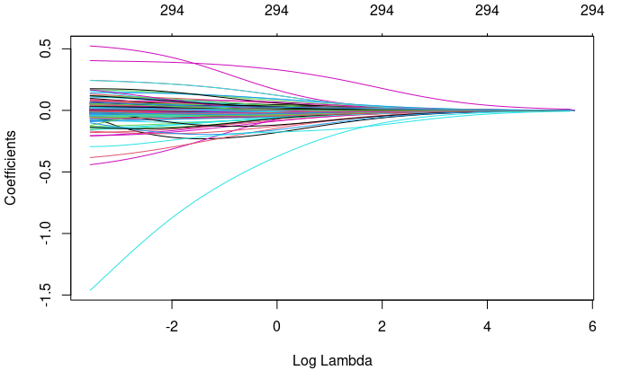

```r
# Apply ridge regression to ames data
ridge <- glmnet(
  x = X,
  y = Y,
  alpha = 0
)

plot(ridge, xvar = "lambda")
```

Figure 6.5: Coefficients for our ridge regression model as λ grows from 0 → ∞.

```r
# lambdas applied to penalty parameter
ridge$lambda %>% head()
```

```
[1] 285.8055 260.4153 237.2807 216.2014 196.9946 179.4942
```

```r
## [1] 285.8055 260.4153 237.2807 216.2014 196.9946 179.4942

# small lambda results in large coefficients
coef(ridge)[c("Latitude", "Overall_QualVery_Excellent"), 100]
```

```
                  Latitude Overall_QualVery_Excellent
                 0.4048216                  0.1423770
```

```r
##                   Latitude Overall_QualVery_Excellent
##                  0.4048216                  0.1423770

# large lambda results in small coefficients
coef(ridge)[c("Latitude", "Overall_QualVery_Excellent"), 1]
```

```
                  Latitude Overall_QualVery_Excellent
              6.382385e-36               9.838114e-37
```

```r
##                                      Latitude
## 0.0000000000000000000000000000000000063823847
##                    Overall_QualVery_Excellent
## 0.0000000000000000000000000000000000009838114
```

#**6.4 Tuning**

[figure not shown]

```r
# Apply CV ridge regression to Ames data
ridge <- cv.glmnet(
  x = X,
  y = Y,
  alpha = 0
)

# Apply CV lasso regression to Ames data
lasso <- cv.glmnet(
  x = X,
  y = Y,
  alpha = 1
)

# plot results
par(mfrow = c(1, 2))
plot(ridge, main = "Ridge penalty\n\n")
plot(lasso, main = "Lasso penalty\n\n")
```

```r
# Ridge model
min(ridge$cvm)       # minimum MSE
```

```
[1] 0.01752896
```

```r
## [1] 0.01748122
ridge$lambda.min     # lambda for this min MSE
```

```
[1] 0.1051301
```

```r
## [1] 0.1051301

ridge$cvm[ridge$lambda == ridge$lambda.1se]  # 1-SE rule
```

```
[1] 0.01965714
```

```r
## [1] 0.01975572
ridge$lambda.1se  # lambda for this MSE
```

```
[1] 0.4657917
```

```r
## [1] 0.4657917

# Lasso model
min(lasso$cvm)       # minimum MSE
```

```
[1] 0.01908478
```

```r
## [1] 0.01754244
lasso$lambda.min     # lambda for this min MSE
```

```
[1] 0.002994143
```

```r
## [1] 0.00248579
lasso$nzero[lasso$lambda == lasso$lambda.min] # No. of coef | Min MSE
```

```
s49
126
```

```r
## s51
## 139

lasso$cvm[lasso$lambda == lasso$lambda.1se]  # 1-SE rule
```

```
[1] 0.02176142
```

```r
## [1] 0.01979976
lasso$lambda.1se  # lambda for this MSE
```

```
[1] 0.01326591
```

```r
## [1] 0.01003518
lasso$nzero[lasso$lambda == lasso$lambda.1se] # No. of coef | 1-SE MSE
```

```
s33
 50
```

```r
## s36
##  64
```

```r
# Ridge model
ridge_min <- glmnet(
  x = X,
  y = Y,
  alpha = 0
)

# Lasso model
lasso_min <- glmnet(
  x = X,
  y = Y,
  alpha = 1
)

par(mfrow = c(1, 2))
# plot ridge model
plot(ridge_min, xvar = "lambda", main = "Ridge penalty\n\n")
abline(v = log(ridge$lambda.min), col = "red", lty = "dashed")
```

```r
abline(v = log(ridge$lambda.1se), col = "blue", lty = "dashed")

# plot lasso model
plot(lasso_min, xvar = "lambda", main = "Lasso penalty\n\n")
```

[figure not shown]

```r
abline(v = log(lasso$lambda.min), col = "red", lty = "dashed")
abline(v = log(lasso$lambda.1se), col = "blue", lty = "dashed")
```

Often, the optimal model contains an alpha somewhere between 0–1, thus we want to tune both the  
λ and the alpha parameters. As in Chapters 4 and 5, we can use the caret package to automate the tuning process. This ensures that any feature engineering is appropriately applied within each resample. The following performs a grid search over 10 values of the alpha parameter between 0–1 and ten values of the lambda parameter from the lowest to highest lambda values identified by glmnet.

```r
library(doParallel)
cl <-makePSOCKcluster(5)
registerDoParallel(cl)
```

```r
# for reproducibility
set.seed(123)

# grid search across
cv_glmnet <- train(
  x = X,
  y = Y,
  method = "glmnet",
  preProc = c("zv", "center", "scale"),
  trControl = trainControl(method = "cv", number = 5),
  tuneLength = 10
)

# model with lowest RMSE
cv_glmnet$bestTune
```

|  | alpha | lambda |
| --- | --- | --- |
| 7 | 0.1 | 0.02007035 |

```r
##   alpha     lambda
## 7   0.1 0.02007035

# results for model with lowest RMSE
cv_glmnet$results %>%
  filter(alpha == cv_glmnet$bestTune$alpha, lambda == cv_glmnet$bestTune$lambda)
```

| alpha | lambda | RMSE | Rsquared | MAE | RMSESD | RsquaredSD | MAESD |
| --- | --- | --- | --- | --- | --- | --- | --- |
| 0.1 | 0.02007035 | 0.1259622 | 0.9041288 | 0.08076988 | 0.02218816 | 0.02658845 | 0.00607787 |

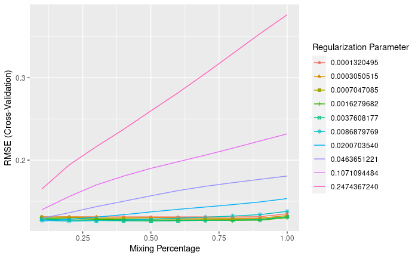

```r
##   alpha     lambda      RMSE  Rsquared        MAE     RMSESD RsquaredSD
## 1   0.1 0.02007035 0.1277585 0.9001487 0.08102427 0.02235901  0.0346677
##         MAESD
## 1 0.005667366

# plot cross-validated RMSE
ggplot(cv_glmnet)
```

```r
# predict sales price on training data
pred <- predict(cv_glmnet, X)

# compute RMSE of transformed predicted
RMSE(exp(pred), exp(Y))
```

```
[1] 19905.05
```

```r
## [1] 19905.05
```

#**6.5 Feature interpretation**

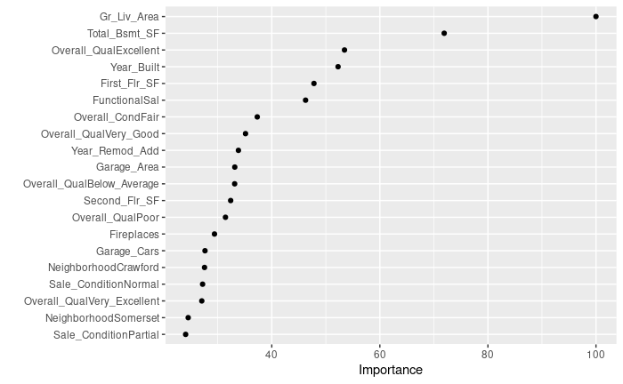

```r
vip(cv_glmnet, num_features = 20, geom = "point")
```

#**6.7 Final thoughts**

Regularized regression provides many great benefits over traditional GLMs when applied to large data sets with lots of features. It provides a great option for handling the n>pproblem, helps minimize the impact of multicollinearity, and can perform automated feature selection. It also has relatively few hyperparameters which makes them easy to tune, computationally efficient compared to other algorithms discussed in later chapters, and memory efficient.

However, regularized regression does require some feature preprocessing. Notably, all inputs must be numeric; however, some packages (e.g., caret and h2o) automate this process. They cannot automatically handle missing data, which requires you to remove or impute them prior to modeling. Similar to GLMs, they are also not robust to outliers in both the feature and target. Lastly, regularized regression models still assume a monotonic linear relationship (always increasing or decreasing in a linear fashion). It is also up to the analyst whether or not to include specific interaction effects.

#**Chapter 7 Multivariate Adaptive Regression Splines**

The previous chapters discussed algorithms that are intrinsically linear. Many of these models can be adapted to nonlinear patterns in the data by manually adding nonlinear model terms (e.g., squared terms, interaction effects, and other transformations of the original features); however, to do so you the analyst must know the specific nature of the nonlinearities and interactions a priori. Alternatively, there are numerous algorithms that are inherently nonlinear. When using these models, the exact form of the nonlinearity does not need to be known explicitly or specified prior to model training. Rather, these algorithms will search for, and discover, nonlinearities and interactions in the data that help maximize predictive accuracy.

This chapter discusses multivariate adaptive regression splines (MARS) (Friedman 1991), an algorithm that automatically creates a piecewise linear model which provides an intuitive stepping block into nonlinearity after grasping the concept of multiple linear regression. Future chapters will focus on other nonlinear algorithms.

```r
# Helper packages
library(dplyr)     # for data wrangling
library(ggplot2)   # for awesome plotting
library(rsample) # for resamples  (initial_split)
# Modeling packages
library(earth)     # for fitting MARS models
library(caret)     # for automating the tuning process

# Model interpretability packages
library(vip)       # for variable importance
library(pdp)       # for variable relationships
```

#**7.3 Fitting a basic MARS model**

```r
# Ames housing data
ames <- AmesHousing::make_ames()
#ames.h2o <- as.h2o(ames)
dim(ames) #2930 rows, 81 columns
```

```
[1] 2930   81
```

```r
set.seed(123)
split <- initial_split(ames, prop = 0.7,
                       strata = "Sale_Price")
ames_train  <- training(split)
ames_test   <- testing(split)
```

```r
# Fit a basic MARS model
mars1 <- earth(
  Sale_Price ~ .,
  data = ames_train
)

# Print model summary
print(mars1)
```

```
Selected 36 of 40 terms, and 28 of 308 predictors
Termination condition: RSq changed by less than 0.001 at 40 terms
Importance: Gr_Liv_Area, Year_Built, Total_Bsmt_SF, Overall_QualExcellent, Overall_QualVery_Good, ...
Number of terms at each degree of interaction: 1 35 (additive model)
GCV 547654257    RSS 1.047912e+12    GRSq 0.9150216    RSq 0.9207205
```

```r
summary(mars1) %>% .$coefficients %>% head(10)
```

```
                             Sale_Price
(Intercept)                234803.84945
h(2787-Gr_Liv_Area)           -50.67882
h(Year_Built-2004)           3595.39940
h(2004-Year_Built)           -373.40103
h(Total_Bsmt_SF-1298)          56.30424
h(1298-Total_Bsmt_SF)         -29.95470
h(Bsmt_Unf_SF-536)            -24.47153
h(536-Bsmt_Unf_SF)             16.28784
Overall_QualExcellent       79769.47075
Overall_QualVery_Excellent 117138.64127
```

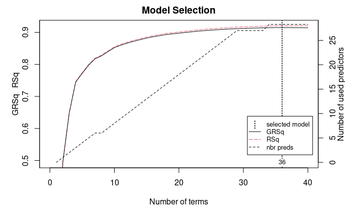

```r
plot(mars1, which = 1)
```

In addition to pruning the number of knots, earth::earth() allows us to also assess potential interactions between different hinge functions. The following illustrates this by including a degree = 2 argument. You can see that now our model includes interaction terms between a maximum of two hinge functions

```r
# Fit a basic MARS model
mars2 <- earth(
  Sale_Price ~ .,
  data = ames_train,
  degree = 2
)

# check out the first 10 coefficient terms
summary(mars2) %>% .$coefficients %>% head(10)
```

```
                                           Sale_Price
(Intercept)                              2.568344e+05
h(Gr_Liv_Area-2787)                     -1.449341e+02
h(2787-Gr_Liv_Area)                     -4.966604e+01
h(Year_Built-2004)                       4.548491e+03
h(2004-Year_Built)                      -7.249201e+02
h(Total_Bsmt_SF-1298)                    8.060668e+01
h(1298-Total_Bsmt_SF)                   -4.196757e+01
h(Bsmt_Unf_SF-1017)*h(2787-Gr_Liv_Area) -2.352446e-02
h(1017-Bsmt_Unf_SF)*h(2787-Gr_Liv_Area)  8.535269e-03
Condition_1Norm*h(Gr_Liv_Area-2787)      2.785045e+02
```

#**7.4 Tuning** #**BEST MODEL** There are two important tuning parameters associated with our MARS model: the maximum degree of interactions and the number of terms retained in the final model. We need to perform a grid search to identify the optimal combination of these hyperparameters that minimize prediction error (the above pruning process was based only on an approximation of CV model performance on the training data rather than an exact k-fold CV process). As in previous chapters, we’ll perform a CV grid search to identify the optimal hyperparameter mix. Below, we set up a grid that assesses 30 different combinations of interaction complexity (degree) and the number of terms to retain in the final model (nprune).

Rarely is there any benefit in assessing greater than 3-rd degree interactions and we suggest starting out with 10 evenly spaced values for nprune and then you can always zoom in to a region once you find an approximate optimal solution.

```r
# create a tuning grid
hyper_grid <- expand.grid(
  degree = 1:3,
  nprune = seq(2, 100, length.out = 10) %>% floor()
)

head(hyper_grid)
```

|  | degree | nprune |
| --- | --- | --- |
| 1 | 1 | 2 |
| 2 | 2 | 2 |
| 3 | 3 | 2 |
| 4 | 1 | 12 |
| 5 | 2 | 12 |
| 6 | 3 | 12 |

```r
library(doParallel)
cl <-makePSOCKcluster(5)
registerDoParallel(cl)
```

VERY IMPORTANT: This grid search took roughly five minutes to complete.

```r
# Cross-validated model
set.seed(123)  # for reproducibility
cv_mars <- train(
  x = subset(ames_train, select = -Sale_Price),
  y = ames_train$Sale_Price,
  method = "earth",
  metric = "RMSE",
  trControl = trainControl(method = "cv", number = 5),
  tuneGrid = hyper_grid
)
```

```r
# View results
cv_mars$bestTune
```

|  | nprune | degree |
| --- | --- | --- |
| 15 | 45 | 2 |

```r
##    nprune degree
## 16     56      2

cv_mars$results %>%
  filter(nprune == cv_mars$bestTune$nprune, degree == cv_mars$bestTune$degree)
```

| degree | nprune | RMSE | Rsquared | MAE | RMSESD | RsquaredSD | MAESD |
| --- | --- | --- | --- | --- | --- | --- | --- |
| 2 | 45 | 27574.67 | 0.8781615 | 16474.27 | 9104.388 | 0.07918645 | 1142.285 |

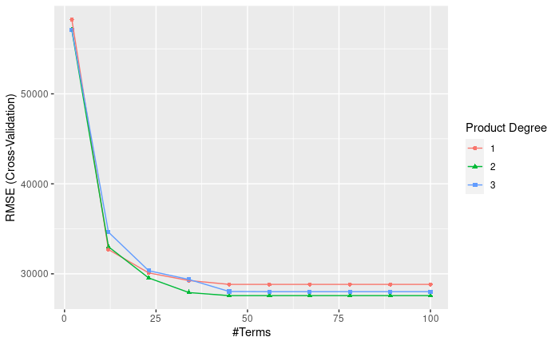

```r
##   degree nprune    RMSE  Rsquared      MAE   RMSESD RsquaredSD    MAESD
## 1      2     56 26817.1 0.8838914 16439.15 11683.73 0.09785945 1678.672

ggplot(cv_mars)
```

The above grid search helps to focus where we can further refine our model tuning. As a next step, we could perform a grid search that focuses in on a refined grid space for nprune (e.g., comparing 45–65 terms retained). However, for brevity we’ll leave this as an exercise for the reader.

```r
cv_mars$resample
```

| RMSE | Rsquared | MAE | Resample |
| --- | --- | --- | --- |
| 43641.00 | 0.7378843 | 17896.47 | Fold3 |
| 23647.77 | 0.9239949 | 16671.80 | Fold2 |
| 25836.28 | 0.8949704 | 17168.07 | Fold1 |
| 21703.51 | 0.9150478 | 15312.95 | Fold5 |
| 23044.81 | 0.9189102 | 15322.07 | Fold4 |

#**7.5 Feature interpretation**

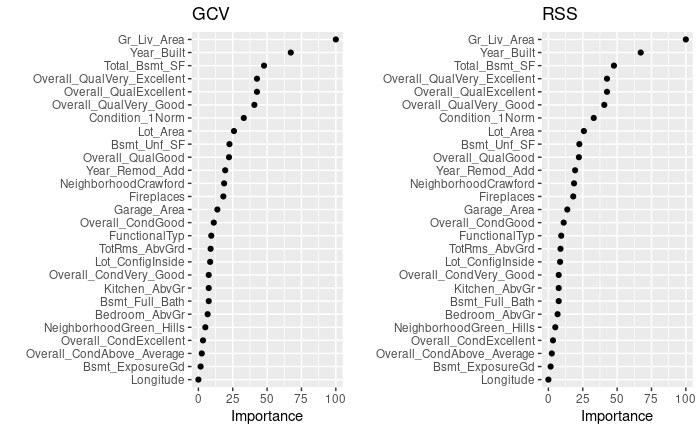

```r
# variable importance plots
p1 <- vip(cv_mars, num_features = 40, geom = "point", value = "gcv") + ggtitle("GCV")
p2 <- vip(cv_mars, num_features = 40, geom = "point", value = "rss") + ggtitle("RSS")

gridExtra::grid.arrange(p1, p2, ncol = 2)
```

Its important to realize that variable importance will only measure the impact of the prediction error as features are included; however, it does not measure the impact for particular hinge functions created for a given feature. For example, in Figure 7.5 we see that Gr_Liv_Area and Year_Built are the two most influential variables; however, variable importance does not tell us how our model is treating the non-linear patterns for each feature. Also, if we look at the interaction terms our model retained, we see interactions between different hinge functions.

```r
# extract coefficients, convert to tidy data frame, and
# filter for interaction terms
cv_mars$finalModel %>%
  coef() %>%
  broom::tidy() %>%
  filter(stringr::str_detect(names, "\\*"))
```

```
'tidy.numeric' is deprecated.
See help("Deprecated")`data_frame()` is deprecated as of tibble 1.1.0.
Please use `tibble()` instead.
```

| names | x |
| --- | --- |
| h(Bsmt_Unf_SF-1017) * h(2787-Gr_Liv_Area) | -2.352446e-02 |
| h(1017-Bsmt_Unf_SF) * h(2787-Gr_Liv_Area) | 8.535269e-03 |
| Condition_1Norm * h(Gr_Liv_Area-2787) | 2.785045e+02 |
| h(2004-Year_Built) * h(Total_Bsmt_SF-1440) | -1.699302e+00 |
| h(2004-Year_Built) * h(1440-Total_Bsmt_SF) | 2.418181e-01 |
| h(17808-Lot_Area) * h(Total_Bsmt_SF-1298) | -5.031133e-03 |
| h(Year_Remod_Add-1973) * h(Gr_Liv_Area-1710) | 1.252034e+00 |
| Overall_QualExcellent * h(Total_Bsmt_SF-1103) | 4.150846e+01 |
| Overall_QualExcellent * h(1103-Total_Bsmt_SF) | -1.561245e+03 |
| h(Year_Remod_Add-1973) * h(TotRms_AbvGrd-10) | 9.113825e+02 |

[output cut: 10 more lines]

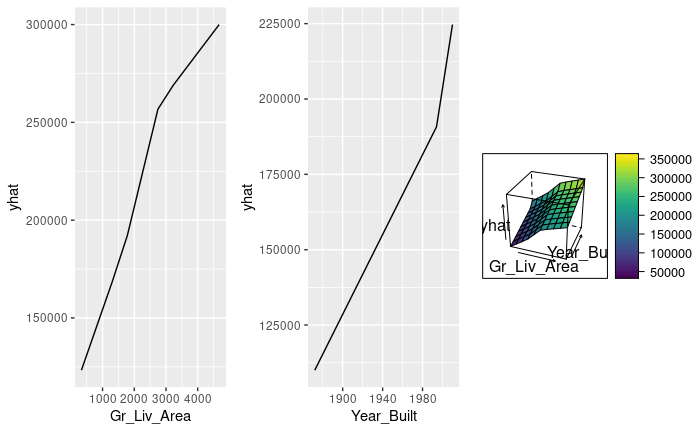

```r
# Construct partial dependence plots
p1 <- partial(cv_mars, pred.var = "Gr_Liv_Area", grid.resolution = 10) %>%
  autoplot()
p2 <- partial(cv_mars, pred.var = "Year_Built", grid.resolution = 10) %>%
  autoplot()
p3 <- partial(cv_mars, pred.var = c("Gr_Liv_Area", "Year_Built"),
              grid.resolution = 10) %>%
  plotPartial(levelplot = FALSE, zlab = "yhat", drape = TRUE, colorkey = TRUE,
              screen = list(z = -20, x = -60))

# Display plots side by side
gridExtra::grid.arrange(p1, p2, p3, ncol = 3)
```

#**7.7 Final thoughts**

There are several advantages to MARS. First, MARS naturally handles mixed types of predictors (quantitative and qualitative). MARS considers all possible binary partitions of the categories for a qualitative predictor into two groups.25 Each group then generates a pair of piecewise indicator functions for the two categories. MARS also requires minimal feature engineering (e.g., feature scaling) and performs automated feature selection. For example, since MARS scans each predictor to identify a split that improves predictive accuracy, non-informative features will not be chosen. Furthermore, highly correlated predictors do not impede predictive accuracy as much as they do with OLS models.

However, one disadvantage to MARS models is that they’re typically slower to train. Since the algorithm scans each value of each predictor for potential cutpoints, computational performance can suffer as both n and p increase. Also, although correlated predictors do not necessarily impede model performance, they can make model interpretation difficult. When two features are nearly perfectly correlated, the algorithm will essentially select the first one it happens to come across when scanning the features. Then, since it randomly selected one, the correlated feature will likely not be included as it adds no additional explanatory power.

#**Chapter 9 Decision Trees** Tree-based models are a class of nonparametric algorithms that work by partitioning the feature space into a number of smaller (non-overlapping) regions with similar response values using a set of splitting rules. Predictions are obtained by fitting a simpler model (e.g., a constant like the average response value) in each region. Such divide-and-conquer methods can produce simple rules that are easy to interpret and visualize with tree diagrams. As we’ll see, decision trees offer many benefits; however, they typically lack in predictive performance compared to more complex algorithms like neural networks and MARS. However, future chapters will discuss powerful ensemble algorithms—like random forests and gradient boosting machines—which are constructed by combining together many decision trees in a clever way. This chapter will provide you with a strong foundation in decision trees.

```r
# Helper packages
library(dplyr)       # for data wrangling
library(ggplot2)     # for awesome plotting
library(rsample) # for resamples  (initial_split)
# Modeling packages
library(rpart)       # direct engine for decision tree application
library(caret)       # meta engine for decision tree application

# Model interpretability packages
library(rpart.plot)  # for plotting decision trees
library(vip)         # for feature importance
library(pdp)         # for feature effects
```

```r
# Ames housing data
ames <- AmesHousing::make_ames()
#ames.h2o <- as.h2o(ames)
dim(ames) #2930 rows, 81 columns
```

```
[1] 2930   81
```

```r
set.seed(123)
split <- initial_split(ames, prop = 0.7,
                       strata = "Sale_Price")
ames_train  <- training(split)
ames_test   <- testing(split)
```

We can fit a regression tree using rpart and then visualize it using rpart.plot. The fitting process and the visual output of regression trees and classification trees are very similar. Both use the formula method for expressing the model (similar to lm()). However, when fitting a regression tree, we need to set method = “anova”. By default, rpart() will make an intelligent guess as to what method to use based on the data type of your response column, but it’s good practice to set this explicitly.

```r
ames_dt1 <- rpart(
  formula = Sale_Price ~ .,
  data    = ames_train,
  method  = "anova"
)
ames_dt1
```

```
n= 2053

node), split, n, deviance, yval
      * denotes terminal node

 1) root 2053 1.321794e+13 180996.30
   2) Overall_Qual=Very_Poor,Poor,Fair,Below_Average,Average,Above_Average,Good 1722 4.107888e+12 156954.70
     4) Neighborhood=North_Ames,Old_Town,Edwards,Sawyer,Mitchell,Brookside,Iowa_DOT_and_Rail_Road,South_and_West_of_Iowa_State_University,Meadow_Village,Briardale,Northpark_Villa,Blueste 1022 1.332227e+12 132318.00
       8) Overall_Qual=Very_Poor,Poor,Fair,Below_Average 199 1.792954e+11  98856.51 *
       9) Overall_Qual=Average,Above_Average,Good 823 8.762399e+11 140409.00
        18) First_Flr_SF< 1089 517 2.905312e+11 129244.00 *
        19) First_Flr_SF>=1089 306 4.123757e+11 159272.60 *
     5) Neighborhood=College_Creek,Somerset,Northridge_Heights,Gilbert,Northwest_Ames,Sawyer_West,Crawford,Timberland,Northridge,Stone_Brook,Clear_Creek,Bloomington_Heights,Veenker,Green_Hills 700 1.249681e+12 192924.20
      10) Gr_Liv_Area< 1477 287 2.508268e+11 165395.90 *
      11) Gr_Liv_Area>=1477 413 6.302277e+11 212054.00
        22) Total_Bsmt_SF< 959.5 199 1.390877e+11 192493.10 *
        23) Total_Bsmt_SF>=959.5 214 3.441912e+11 230243.70 *
   3) Overall_Qual=Very_Good,Excellent,Very_Excellent 331 2.936700e+12 306070.70
     6) Overall_Qual=Very_Good 231 9.469746e+11 270626.10
      12) Gr_Liv_Area< 1919 142 3.349783e+11 244016.60 *
      13) Gr_Liv_Area>=1919 89 3.510308e+11 313081.60 *
     7) Overall_Qual=Excellent,Very_Excellent 100 1.029126e+12 387948.00
      14) Total_Bsmt_SF< 1907.5 72 3.149859e+11 350532.40 *
      15) Total_Bsmt_SF>=1907.5 28 3.541599e+11 484159.40 *
```

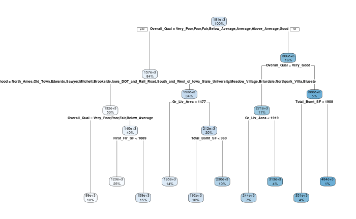

```r
rpart.plot(ames_dt1)
```

Prunning:

An alternative to explicitly specifying the depth of a decision tree is to grow a very large, complex tree and then prune it back to find an optimal subtree. We find the optimal subtree by using a cost complexity parameter ( α ) that penalizes our objective function in Equation (9.1) for the number of terminal nodes of the tree ( T) as in Equation (9.2).

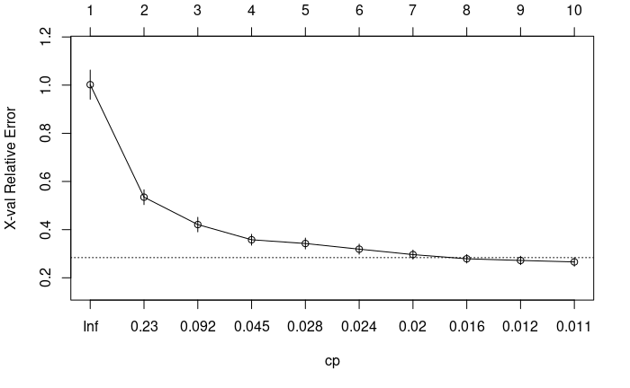

```r
plotcp(ames_dt1)
```

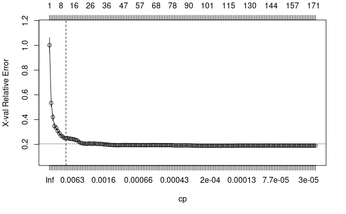

```r
ames_dt2 <- rpart(
    formula = Sale_Price ~ .,
    data    = ames_train,
    method  = "anova",
    control = list(cp = 0, xval = 10)
)

plotcp(ames_dt2)
abline(v = 11, lty = "dashed")
```

```r
# rpart cross validation results
ames_dt1$cptable
##            CP nsplit rel error    xerror       xstd
## 1  0.47940879      0 1.0000000 1.0014737 0.06120398
## 2  0.11290476      1 0.5205912 0.5226036 0.03199501
## 3  0.06999005      2 0.4076864 0.4098819 0.03111581
## 4  0.02758522      3 0.3376964 0.3572726 0.02222507
## 5  0.02347276      4 0.3101112 0.3339952 0.02184348
## 6  0.02201070      5 0.2866384 0.3301630 0.02446178
## 7  0.02039233      6 0.2646277 0.3244948 0.02421833
## 8  0.01190364      7 0.2442354 0.3062031 0.02641595
## 9  0.01116365      8 0.2323317 0.3025968 0.02708786
## 10 0.01103581      9 0.2211681 0.2971663 0.02704837
## 11 0.01000000     10 0.2101323 0.2920442 0.02704791
```

#**BESTMODEL**

```r
# rpart cross validation results
ames_dt1$cptable
```

```
           CP nsplit rel error    xerror       xstd
1  0.46704344      0 1.0000000 1.0019543 0.06055702
2  0.11544770      1 0.5329566 0.5347883 0.03087896
3  0.07267387      2 0.4175089 0.4209819 0.03015640
4  0.02788834      3 0.3448350 0.3579514 0.02262208
5  0.02723422      4 0.3169466 0.3423830 0.02260172
6  0.02093301      5 0.2897124 0.3189084 0.02089513
7  0.01974328      6 0.2687794 0.2963231 0.01882609
8  0.01311346      7 0.2490361 0.2789510 0.01765181
9  0.01111737      8 0.2359227 0.2720967 0.01747691
10 0.01000000      9 0.2248053 0.2659597 0.01776767
```

```r
##            CP nsplit rel error    xerror       xstd
## 1  0.47940879      0 1.0000000 1.0014737 0.06120398
## 2  0.11290476      1 0.5205912 0.5226036 0.03199501
## 3  0.06999005      2 0.4076864 0.4098819 0.03111581
## 4  0.02758522      3 0.3376964 0.3572726 0.02222507
## 5  0.02347276      4 0.3101112 0.3339952 0.02184348
## 6  0.02201070      5 0.2866384 0.3301630 0.02446178
## 7  0.02039233      6 0.2646277 0.3244948 0.02421833
## 8  0.01190364      7 0.2442354 0.3062031 0.02641595
## 9  0.01116365      8 0.2323317 0.3025968 0.02708786
## 10 0.01103581      9 0.2211681 0.2971663 0.02704837
## 11 0.01000000     10 0.2101323 0.2920442 0.02704791

# caret cross validation results
ames_dt3 <- train(
  Sale_Price ~ .,
  data = ames_train,
  method = "rpart",
  trControl = trainControl(method = "cv", number = 10),
  tuneLength = 20
)
```

```
There were missing values in resampled performance measures.
```

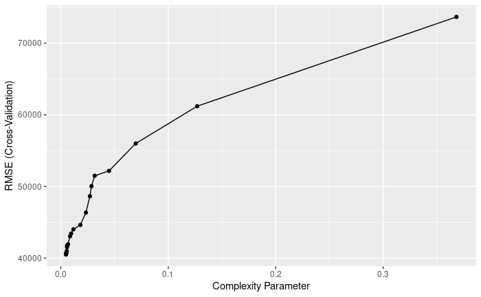

```r
ggplot(ames_dt3)
```

#**9.6 Feature interpretation**

```
The `bar` argument has been deprecated in favor of the new `geom` argument. It will be removed in version 0.3.0.
```

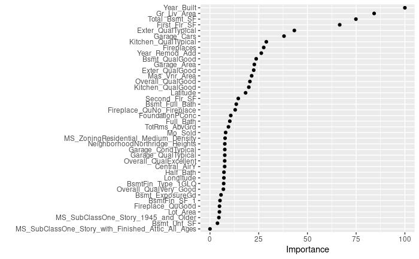

```r
vip(ames_dt3, num_features = 40, bar = FALSE)
```

```r
# Construct partial dependence plots
p1 <- partial(ames_dt3, pred.var = "Gr_Liv_Area") %>% autoplot()
p2 <- partial(ames_dt3, pred.var = "Year_Built") %>% autoplot()
p3 <- partial(ames_dt3, pred.var = c("Gr_Liv_Area", "Year_Built")) %>%
  plotPartial(levelplot = FALSE, zlab = "yhat", drape = TRUE,
              colorkey = TRUE, screen = list(z = -20, x = -60))
```

#**Chapter 10 Bagging**

In Section 2.4.2 we learned about bootstrapping as a resampling procedure, which creates b new bootstrap samples by drawing samples with replacement of the original training data. This chapter illustrates how we can use bootstrapping to create an ensemble of predictions. Bootstrap aggregating, also called bagging, is one of the first ensemble algorithms28 machine learning practitioners learn and is designed to improve the stability and accuracy of regression and classification algorithms. By model averaging, bagging helps to reduce variance and minimize overfitting. Although it is usually applied to decision tree methods, it can be used with any type of method.

```r
# Helper packages
library(dplyr)       # for data wrangling
library(ggplot2)     # for awesome plotting
library(doParallel)  # for parallel backend to foreach
library(foreach)     # for parallel processing with for loops

# Modeling packages
library(caret)       # for general model fitting
library(rpart)       # for fitting decision trees
library(ipred)       # for fitting bagged decision trees
```

The bagging() function comes from the ipred package and we use nbagg to control how many iterations to include in the bagged model and coob = TRUE indicates to use the OOB error rate. By default, bagging() uses rpart::rpart() for decision tree base learners but other base learners are available. Since bagging just aggregates a base learner, we can tune the base learner parameters as normal. Here, we pass parameters to rpart() with the control parameter and we build deep trees (no pruning) that require just two observations in a node to split.

```r
# make bootstrapping reproducible
set.seed(123)

# train bagged model
ames_bag1 <- bagging(
  formula = Sale_Price ~ .,
  data = ames_train,
  nbagg = 100,
  coob = TRUE,
  control = rpart.control(minsplit = 2, cp = 0)
)

ames_bag1
```

```
Bagging regression trees with 100 bootstrap replications

Call: bagging.data.frame(formula = Sale_Price ~ ., data = ames_train,
    nbagg = 100, coob = TRUE, control = rpart.control(minsplit = 2,
        cp = 0))

Out-of-bag estimate of root mean squared error:  27767.13
```

```r
##
## Bagging regression trees with 100 bootstrap replications
##
## Call: bagging.data.frame(formula = Sale_Price ~ ., data = ames_train,
##     nbagg = 100, coob = TRUE, control = rpart.control(minsplit = 2,
##         cp = 0))
##
## Out-of-bag estimate of root mean squared error:  25528.78
```

```r
cl <- makeCluster(8) # use 8 workers
registerDoParallel(cl) # register the parallel backend

ames_bag2 <- train(
  Sale_Price ~ .,
  data = ames_train,
  method = "treebag",
  trControl = trainControl(method = "cv", number = 5),
  nbagg = 200,
  control = rpart.control(minsplit = 2, cp = 0)
)
```

#**10.4 Easily parallelize** As stated in Section 10.2, bagging can become computationally intense as the number of iterations increases. Fortunately, the process of bagging involves fitting models to each of the bootstrap samples which are completely independent of one another. This means that each model can be trained in parallel and the results aggregated in the end for the final model. Consequently, if you have access to a large cluster or number of cores, you can more quickly create bagged ensembles on larger data sets.

The following illustrates parallelizing the bagging algorithm (with b=160 decision trees) on the Ames housing data using eight cores and returning the predictions for the test data for each of the trees.

```r
# Create a parallel socket cluster
cl <- makeCluster(8) # use 8 workers
registerDoParallel(cl) # register the parallel backend

# Fit trees in parallel and compute predictions on the test set
predictions <- foreach(
  icount(160),
  .packages = "rpart",
  .combine = cbind
  ) %dopar% {
    # bootstrap copy of training data
    index <- sample(nrow(ames_train), replace = TRUE)
    ames_train_boot <- ames_train[index, ]

    # fit tree to bootstrap copy
    bagged_tree <- rpart(
      Sale_Price ~ .,
      control = rpart.control(minsplit = 2, cp = 0),
      data = ames_train_boot
      )

    predict(bagged_tree, newdata = ames_test)
}

predictions[1:5, 1:7]
```

```
  result.1 result.2 result.3 result.4 result.5 result.6 result.7
1   243000   225000   167300   147000   229000   187500   143000
2   189500   180000   180000   189500   182000   183000   200500
3   189000   162500   213500   164000   180000   130000   236500
4   183600   160000   190000   158000   167840   173000   174000
5   130000   236500   213500   214000   130000   187500   236500
```

```r
##   result.1 result.2 result.3 result.4 result.5 result.6 result.7
## 1   176500   187000   179900   187500   187500   187500   187500
## 2   180000   254000   251000   240000   180000   180000   221000
## 3   175000   174000   192000   192000   185000   178900   163990
## 4   197900   157000   217500   215000   180000   210000   218500
## 5   120000   129000   130000   143000   136500   153600   148500
```

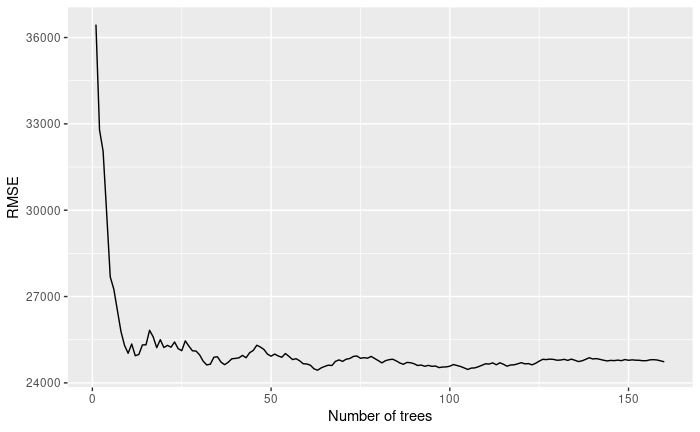

```r
predictions %>%
  as.data.frame() %>%
  mutate(
    observation = 1:n(),
    actual = ames_test$Sale_Price) %>%
  tidyr::gather(tree, predicted, -c(observation, actual)) %>%
  group_by(observation) %>%
  mutate(tree = stringr::str_extract(tree, '\\d+') %>% as.numeric()) %>%
  ungroup() %>%
  arrange(observation, tree) %>%
  group_by(observation) %>%
  mutate(avg_prediction = cummean(predicted)) %>%
  group_by(tree) %>%
  summarize(RMSE = RMSE(avg_prediction, actual)) %>%
  ggplot(aes(tree, RMSE)) +
  geom_line() +
  xlab('Number of trees')
```

```r
# Shutdown parallel cluster
stopCluster(cl)
```

#**10.5 Feature interpretation**

```r
vip::vip(ames_bag1, num_features = 40, bar = FALSE)
```

```
The `bar` argument has been deprecated in favor of the new `geom` argument. It will be removed in version 0.3.0.Error: Model-specific variable importance scores are currently not available for this type of model.
```

```r
# Construct partial dependence plots
p1 <- pdp::partial(
  ames_bag2,
  pred.var = "Lot_Area",
  grid.resolution = 20
  ) %>%
  autoplot()

p2 <- pdp::partial(
  ames_bag2,
  pred.var = "Lot_Frontage",
  grid.resolution = 20
  ) %>%
  autoplot()

gridExtra::grid.arrange(p1, p2, nrow = 1)
```

[output not shown]

#**Chapter 11 Random Forests**

Random forests are a modification of bagged decision trees that build a large collection of de-correlated trees to further improve predictive performance. They have become a very popular “out-of-the-box” or “off-the-shelf” learning algorithm that enjoys good predictive performance with relatively little hyperparameter tuning. Many modern implementations of random forests exist; however, Leo Breiman’s algorithm (Breiman 2001) has largely become the authoritative procedure. This chapter will cover the fundamentals of random forests.

```r
#install.packages("ranger")
# Helper packages
library(dplyr)    # for data wrangling
library(ggplot2)  # for awesome graphics
library(rsample) # for resamples  (initial_split)

# Modeling packages
library(ranger)   # a c++ implementation of random forest
library(h2o)      # a java-based implementation of random forest
```

#**11.2 Extending bagging**

1. Given a training data set
2. Select number of trees to build (n_trees)
3. for i = 1 to n_trees do
4. Generate a bootstrap sample of the original data
5. Grow a regression/classification tree to the bootstrapped data
6. for each split do
7. | Select m_try variables at random from all p variables
8. | Pick the best variable/split-point among the m_try
9. | Split the node into two child nodes
10. end
11. Use typical tree model stopping criteria to determine when a  
    tree is complete (but do not prune)
12. end
13. Output ensemble of trees

When m try = p, the algorithm is equivalent to bagging decision trees.

```r
# Ames housing data
ames <- AmesHousing::make_ames()
#ames.h2o <- as.h2o(ames)
dim(ames) #2930 rows, 81 columns
```

```
[1] 2930   81
```

```r
set.seed(123)
split <- initial_split(ames, prop = 0.7,
                       strata = "Sale_Price")
ames_train  <- training(split)
ames_test   <- testing(split)
```

```r
# number of features
n_features <- length(setdiff(names(ames_train), "Sale_Price"))
print(n_features)
```

```
[1] 80
```

```r
# train a default random forest model
ames_rf1 <- ranger(
  Sale_Price ~ .,
  data = ames_train,
  mtry = floor(n_features / 3),
  respect.unordered.factors = "order",
  seed = 123
)

# get OOB RMSE
(default_rmse <- sqrt(ames_rf1$prediction.error))
```

```
[1] 25896.47
```

```r
## [1] 24859.27
```

```r
ames_rf1
```

```
Ranger result

Call:
 ranger(Sale_Price ~ ., data = ames_train, mtry = floor(n_features/3),      respect.unordered.factors = "order", seed = 123)

Type:                             Regression
Number of trees:                  500
Sample size:                      2053
Number of independent variables:  80
Mtry:                             26
Target node size:                 5
Variable importance mode:         none
Splitrule:                        variance
OOB prediction error (MSE):       670627329
R squared (OOB):                  0.8958894
```

#11.4 Hyperparameters

- The number of trees in the forest
- The number of features to consider at any given split: m try
- The complexity of each tree
- The sampling scheme
- The splitting rule to use during tree construction

This grid search takes approximately 2 minutes. #**ranger Grid search**

```r
# create hyperparameter grid
hyper_grid <- expand.grid(
  mtry = floor(n_features * c(.05, .15, .25, .333, .4)),
  min.node.size = c(1, 3, 5, 10),
  replace = c(TRUE, FALSE),
  sample.fraction = c(.5, .63, .8),
  rmse = NA
)
print(hyper_grid)
```

| mtry | min.node.size | replace | sample.fraction | rmse |
| --- | --- | --- | --- | --- |
| 4 | 1 | TRUE | 0.50 | NA |
| 12 | 1 | TRUE | 0.50 | NA |
| 20 | 1 | TRUE | 0.50 | NA |
| 26 | 1 | TRUE | 0.50 | NA |
| 32 | 1 | TRUE | 0.50 | NA |
| 4 | 3 | TRUE | 0.50 | NA |
| 12 | 3 | TRUE | 0.50 | NA |
| 20 | 3 | TRUE | 0.50 | NA |
| 26 | 3 | TRUE | 0.50 | NA |
| 32 | 3 | TRUE | 0.50 | NA |

[output cut: 110 more lines]

```r
# execute full cartesian grid search
for(i in seq_len(nrow(hyper_grid))) {
  # fit model for ith hyperparameter combination
  fit <- ranger(
    formula         = Sale_Price ~ .,
    data            = ames_train,
    num.trees       = n_features * 10,
    mtry            = hyper_grid$mtry[i],
    min.node.size   = hyper_grid$min.node.size[i],
    replace         = hyper_grid$replace[i],
    sample.fraction = hyper_grid$sample.fraction[i],
    verbose         = FALSE,
    seed            = 123,
    respect.unordered.factors = 'order',
  )
  # export OOB error
  hyper_grid$rmse[i] <- sqrt(fit$prediction.error)
}
```

However, as we add more hyperparameters and values to search across and as our data sets become larger, you can see how a full Cartesian search can become exhaustive and computationally expensive. In addition to full Cartesian search, the h2o package provides a random grid search that allows you to jump from one random combination to another and it also provides early stopping rules that allow you to stop the grid search once a certain condition is met (e.g., a certain number of models have been trained, a certain runtime has elapsed, or the accuracy has stopped improving by a certain amount). Although using a random discrete search path will likely not find the optimal model, it typically does a good job of finding a very good model.

To fit a random forest model with h2o, we first need to initiate our h2o session. #**H2O implementation**

```r
h2o_rf1
```

```
Model Details:
==============

H2ORegressionModel: drf
Model ID:  DRF_model_R_1606813819331_1
Model Summary:
```

|  | number_of_trees | number_of_internal_trees | model_size_in_bytes | min_depth | max_depth | mean_depth | min_leaves | max_leaves | mean_leaves |
| --- | --- | --- | --- | --- | --- | --- | --- | --- | --- |
| 1 | 800 | 800 | 12392984 | 20 | 20 | 20.00000 | 1130 | 1291 | 1227.79750 |

```
H2ORegressionMetrics: drf
** Reported on training data. **
** Metrics reported on Out-Of-Bag training samples **

MSE:  680109951
RMSE:  26078.92
MAE:  15451.62
RMSLE:  0.1349113
Mean Residual Deviance :  680109951
```

```r
# hyperparameter grid
hyper_grid <- list(
  mtries = floor(n_features * c(.05, .15, .25, .333, .4)),
  min_rows = c(1, 3, 5, 10),
  max_depth = c(10, 20, 30),
  sample_rate = c(.55, .632, .70, .80)
)

# random grid search strategy
search_criteria <- list(
  strategy = "RandomDiscrete",
  stopping_metric = "mse",
  stopping_tolerance = 0.001,   # stop if improvement is < 0.1%
  stopping_rounds = 10,         # over the last 10 models
  max_runtime_secs = 60*5      # or stop search after 5 min.
)
```

This grid search takes 5 minutes.

```r
# perform grid search
random_grid <- h2o.grid(
  algorithm = "randomForest",
  grid_id = "rf_random_grid",
  x = predictors,
  y = response,
  training_frame = train_h2o,
  hyper_params = hyper_grid,
  ntrees = n_features * 10,
  seed = 123,
  stopping_metric = "RMSE",
  stopping_rounds = 10,           # stop if last 10 trees added
  stopping_tolerance = 0.005,     # don't improve RMSE by 0.5%
  search_criteria = search_criteria
)
```

```r
# collect the results and sort by our model performance metric
# of choice
random_grid_perf <- h2o.getGrid(
  grid_id = "rf_random_grid",
  sort_by = "mse",
  decreasing = FALSE
)
random_grid_perf
```

[output not shown]

#11.6 Feature interpretation

```r
# re-run model with impurity-based variable importance
rf_impurity <- ranger(
  formula = Sale_Price ~ .,
  data = ames_train,
  num.trees = 2000,
  mtry = 32,
  min.node.size = 1,
  sample.fraction = .80,
  replace = FALSE,
  importance = "impurity",
  respect.unordered.factors = "order",
  verbose = FALSE,
  seed  = 123
)

# re-run model with permutation-based variable importance
rf_permutation <- ranger(
  formula = Sale_Price ~ .,
  data = ames_train,
  num.trees = 2000,
  mtry = 32,
  min.node.size = 1,
  sample.fraction = .80,
  replace = FALSE,
  importance = "permutation",
  respect.unordered.factors = "order",
  verbose = FALSE,
  seed  = 123
)
```

```r
p1 <- vip::vip(rf_impurity, num_features = 25, bar = FALSE)
```

```
The `bar` argument has been deprecated in favor of the new `geom` argument. It will be removed in version 0.3.0.
```

```r
p2 <- vip::vip(rf_permutation, num_features = 25, bar = FALSE)
```

```
The `bar` argument has been deprecated in favor of the new `geom` argument. It will be removed in version 0.3.0.
```

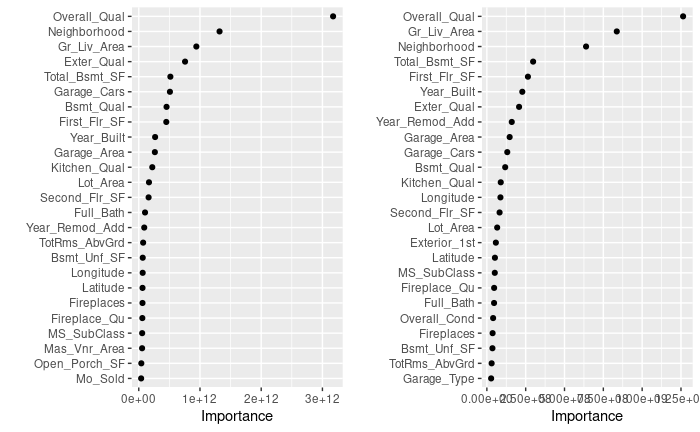

```r
gridExtra::grid.arrange(p1, p2, nrow = 1)
```